# Unsupervised Learning on Country Data

A dataset of countries and various metrics (child mortality, GDP per person, ...) that indicate how "developed" they are. The goal is to identify the countries that are most in need of aid from an NGO.

From Kaggle: https://www.kaggle.com/datasets/rohan0301/unsupervised-learning-on-country-data/data

(The wording is yikes-inducing, as it describes them as "backward" countries).

Here, we implement 2 methods to cluster the countries: k-means and the gaussian mixture model. To determine the optimal number of clusters, k, we use a combination of the silhouette method and the elbow method. Furthermore, for each value of k, we run the clustering multiple times and pick the "best" clustering (according to the silhouette method), just in case there's an unlucky run due to the random starting parameters being bad.

### Imports

```python
import pandas as pd
from sklearn.decomposition import PCA
from scipy.stats import multivariate_normal
import matplotlib.pyplot as plt
from matplotlib.ticker import MaxNLocator
import numpy as np
import random
```

### Reading and preprocessing the data

Note: I renamed the data files.

```python
df = pd.read_csv("countries/data.csv")
df
```

|  | country | child_mort | exports | health | imports | income | inflation | life_expec | total_fer | gdpp |
| --- | --- | --- | --- | --- | --- | --- | --- | --- | --- | --- |
| 0 | Afghanistan | 90.2 | 10.0 | 7.58 | 44.9 | 1610 | 9.44 | 56.2 | 5.82 | 553 |
| 1 | Albania | 16.6 | 28.0 | 6.55 | 48.6 | 9930 | 4.49 | 76.3 | 1.65 | 4090 |
| 2 | Algeria | 27.3 | 38.4 | 4.17 | 31.4 | 12900 | 16.10 | 76.5 | 2.89 | 4460 |
| 3 | Angola | 119.0 | 62.3 | 2.85 | 42.9 | 5900 | 22.40 | 60.1 | 6.16 | 3530 |
| 4 | Antigua and Barbuda | 10.3 | 45.5 | 6.03 | 58.9 | 19100 | 1.44 | 76.8 | 2.13 | 12200 |
| ... | ... | ... | ... | ... | ... | ... | ... | ... | ... | ... |
| 162 | Vanuatu | 29.2 | 46.6 | 5.25 | 52.7 | 2950 | 2.62 | 63.0 | 3.50 | 2970 |
| 163 | Venezuela | 17.1 | 28.5 | 4.91 | 17.6 | 16500 | 45.90 | 75.4 | 2.47 | 13500 |
| 164 | Vietnam | 23.3 | 72.0 | 6.84 | 80.2 | 4490 | 12.10 | 73.1 | 1.95 | 1310 |
| 165 | Yemen | 56.3 | 30.0 | 5.18 | 34.4 | 4480 | 23.60 | 67.5 | 4.67 | 1310 |
| 166 | Zambia | 83.1 | 37.0 | 5.89 | 30.9 | 3280 | 14.00 | 52.0 | 5.40 | 1460 |

167 rows × 10 columns

```python
for i, row in pd.read_csv("countries/dictionary.csv").iterrows():
    print(row["Column Name"] + ":")
    print("  ", row["Description"])
```

```
country:
   Name of the country
child_mort:
   Death of children under 5 years of age per 1000 live births
exports:
   Exports of goods and services per capita. Given as %age of the GDP per capita
health:
   Total health spending per capita. Given as %age of GDP per capita
imports:
   Imports of goods and services per capita. Given as %age of the GDP per capita
Income:
   Net income per person
Inflation:
   The measurement of the annual growth rate of the Total GDP
life_expec:
   The average number of years a new born child would live if the current mortality patterns are to remain the same
total_fer:
   The number of children that would be born to each woman if the current age-fertility rates remain the same.
gdpp:
   The GDP per capita. Calculated as the Total GDP divided by the total population.
```

Normalise the data.

```python
for name in ["child_mort", "exports", "health", "imports",
             "income", "inflation", "life_expec",
             "total_fer", "gdpp"]:
    df[name] -= df[name].mean()
    df[name] /= df[name].std()
```

```python
print(df["income"].mean(), df["income"].std())
```

```
-7.711728793803483e-17 1.0
```

Visualise using PCA.

```python
pca = PCA(n_components=2)
plottable = pca.fit_transform(df.drop(["country"], axis=1))
```

Plotting in 2 dimensions with PCA. There's already a clear gradient from left to right, with poorer countries off to the left. There are also weird, small, tax haven countries off on their own in the top right.

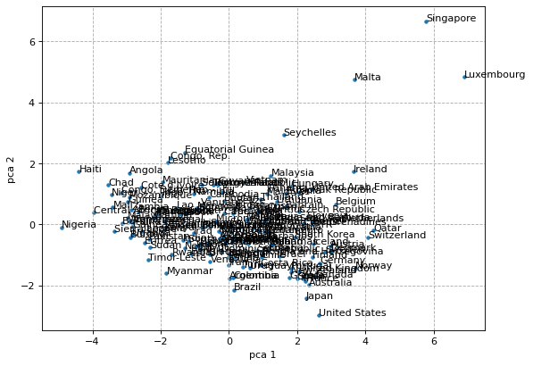

```python
plt.figure(figsize=(8, 6), dpi=80)
plt.scatter(plottable[:,0], plottable[:,1], marker=".")
plt.xlabel("pca 1")
plt.ylabel("pca 2")
plt.grid(linestyle="--")
for name, (x, y) in zip(df["country"], plottable):
    plt.text(x, y, name)
```

### Metrics for clustering

```python
def silhouette_score(X, k, clusters):
    """Calculate the silhouette score for a dataset `X`, `k` clusters and
    cluster assignments `clusters`."""
    silhouette_score = 0
    cluster_ids, gt0_counts = np.unique(clusters, return_counts=True)
    counts = np.zeros(k)
    for cluster_id, count, in zip(cluster_ids, gt0_counts):
        counts[cluster_id] = count
    for i in range(k):
        cluster = X[clusters == i]
        for x in cluster:
            silhouette_score += _calc_silhouette_score(x, X, cluster, clusters, counts, i, k)
    return silhouette_score/len(X)

def _calc_silhouette_score(x, X, cluster, clusters, counts, i, k):
    if counts[i] == 1:
        return 0
    # Average difference from x to the other points in its cluster.
    # It's okay that we don't exclude x from the mask because the
    # distance from x to x is 0, obvs.
    sim_score = (1/(counts[i]-1)) * np.sum(np.sqrt(np.sum((x-cluster)**2, axis=1)))
    dissim_score = min(_calc_dissim_score(x, X, clusters, counts, j)
                       for j in range(k)
                       if j != i)
    return (dissim_score - sim_score)/max(sim_score, dissim_score)

def _calc_dissim_score(x, X, clusters, counts, j):
    if counts[j] == 0:
        return 0
    # Really need to extract the euclidean distance thing into a function.
    return np.sum(np.sqrt(np.sum((x-X[clusters == j])**2, axis=1))) / counts[j]
```

### Implementation of k-means clustering

```python
class KMeans:
    def __init__(self, k):
        self.k = k

    def fit(self, X, max_rounds=100, starting_centers=None):
        minmaxes = list(zip(np.min(X, axis=0), np.max(X, axis=0)))
        if starting_centers is None:
            self.C = np.array([[random.uniform(minval, maxval)
                                for minval, maxval in minmaxes]
                               for _ in range(self.k)])
        else:
            self.C = starting_centers
        self.groups = np.zeros(len(X), dtype=np.uint)
        # Repeatedly assign datapoints to clusters and update the
        # centroids, until convergence.
        self.rounds = 0
        while self.rounds < max_rounds:
            num_changed = self._update_centroids(X)
            self.rounds += 1
            if num_changed == 0:
                break

        self.group_sizes = dict([(group_id, 0) for group_id in range(self.k)])
        unique, counts = np.unique(self.groups, return_counts=True)
        for group_id, count in zip(unique, counts):
            self.group_sizes[group_id] = count

    def _update_centroids(self, X):
        new_groups = np.zeros_like(self.groups)
        for i, x in enumerate(X):
            diffs = np.sum((self.C - x)**2, axis=1)
            new_groups[i] = np.argmin(diffs)
        num_changed = np.sum(self.groups != new_groups)
        self.groups[:] = new_groups
        if num_changed > 0:
            for group_idx in range(self.k):
                mask = self.groups == group_idx
                if np.sum(mask) != 0:
                    self.C[group_idx] = np.mean(X[mask], axis=0)
        return num_changed

    def compute_sq_dist_sum(self, X):
        """Once the clusters have been established via `fit(...)`, this metric
        gives the squared Euclidean distance from each point to the center of its cluster.
        """
        s = 0
        for i, c in enumerate(self.C):
            s += np.sum((X[self.groups == i] - c)**2)
        return s
```

Test it out on sample data

```python
X1 = np.array([-5, 0]) + np.random.normal(size=(10,2), scale=.5)
X2 = np.array([5, 0]) + np.random.normal(size=(10,2), scale=.5)
X = np.vstack([X1, X2])
model = KMeans(2)
model.fit(X)
```

[output not shown]

```
centroids [[ 5.25385166 -0.1102428 ]
 [-5.06643466 -0.12965083]]
rounds 3
group assignments [1 1 1 1 1 1 1 1 1 1 0 0 0 0 0 0 0 0 0 0]
```

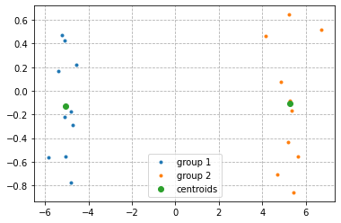

```python
plt.scatter(*zip(*X1), label="group 1", marker=".")
plt.scatter(*zip(*X2), label="group 2", marker=".")
plt.scatter(*zip(*model.C), label="centroids")
print("centroids", model.C)
print("rounds", model.rounds)
print("group assignments", model.groups)
plt.grid(linestyle="--")
plt.legend()
```

### Applying 2-means clustering to the actual country data

Fit the model.

```python
model = KMeans(2)
model.fit(df.drop(["country"], axis=1).to_numpy())
```

```python
print("rounds", model.rounds)
```

```
rounds 10
```

Visualise again with PCA, this time coloured by group.

```python
pca = PCA(n_components=2)
pca_data = pca.fit_transform(df.drop(["country"], axis=1))
```

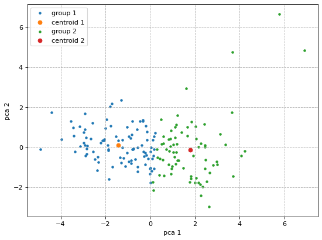

```python
plt.figure(figsize=(8, 6), dpi=80)
for group_id in range(model.k):
    plt.scatter(*zip(*pca_data[model.groups==group_id]),
                marker=".",
                label=f"group {group_id+1}")
    # Apply PCA transform to centroid as well.
    plt.scatter(*pca.transform([model.C[group_id]])[0],
                marker="o",
                label=f"centroid {group_id+1}")
plt.xlabel("pca 1")
plt.ylabel("pca 2")
plt.grid(linestyle="--")
plt.legend()
```

We do seem to have captured most of the wealthy countries in Group 2, and most of the poorer countries in Group 1. However, there's a significant amount of overlap, and the cutoff seems somewhat arbitrary. Perhaps we can get a more granular view by increasing the number of groups `k`.

Another possibility: may need to look at algorithms besides k-means, that separate "extreme" examples from "normal" examples, as it's the "extremely poor" countries that are most likely to be in need of aid.

```python
for group_id in range(model.k):
    print(f"Group {group_id+1}:")
    print("  ", ", ".join(list(df["country"][np.where(model.groups == group_id)[0]])))
```

[output not shown]

### Using metrics to determine an appropriate number of clusters

First try the elbow method. What's the average distance from each point to the center of its group? Note: this may be sensitive to the random centers we start with.

```python
X = df.drop(["country"], axis=1).to_numpy()
```

```python
ks = [2, 3, 4, 5, 6]
avg_dists = []
for k in ks:
    model = KMeans(k)
    model.fit(X)
    avg_dists.append(model.compute_sq_dist_sum(X))
```

```
(0.0, 1430.0654607818988)
```

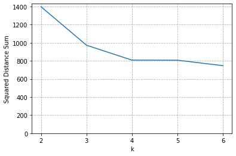

```python
plt.plot(ks, avg_dists)
plt.xlabel("k")
plt.ylabel("Squared Distance Sum")
plt.grid(linestyle="--")
plt.axes().xaxis.set_major_locator(MaxNLocator(integer=True))
plt.ylim(bottom=0)
```

Eyeballing the plot above, the "elbow" seems to be at `k=3` or `k=4`, though the shape varies wildly between runs. So I think it depends a lot on the centres we start with. Let's try the silhouette method, and also do multiple runs for each `k` to hopefully mitigate the issue of bad starting centers.

```python
runs_per_k = 5
ks = [2, 3, 4, 5, 6]
best_Cs = []
scores = []
for k in ks:
    print("k:", k)
    # actual scores be between -1 and +1, so this will
    # be overwritten immediately.
    score = -2
    C = None
    for _ in range(runs_per_k):
        model = KMeans(k)
        model.fit(X)
        new_score = silhouette_score(X, k, model.groups)
        if new_score > score:
            C = model.C
            score = new_score
    best_Cs.append(C)
    scores.append(score)
```

```
k: 2
k: 3
k: 4
k: 5
k: 6
```

```
(-1.0, 1.0)
```

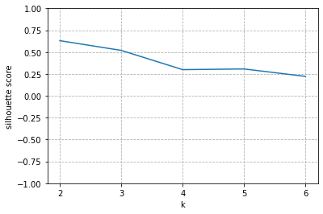

```python
plt.plot(ks, scores)
plt.xlabel("k")
plt.ylabel("silhouette score")
plt.axes().xaxis.set_major_locator(MaxNLocator(integer=True))
plt.grid(linestyle="--")
plt.ylim(bottom=-1, top=1)
```

Between the silhouette score and the elbow method, the ideal number of clusters seems to be `k=2` or `k=3`. In any case, let's see what the clustering looks like with `k=3` and `k=4`, reusing the centers that we got from the parameter testing.

```python
def fit_and_plot(X, k, ks, best_Cs):
    k_index = ks.index(k)
    # Reusing the best centers that we got above, should converge in 1 round.
    model = KMeans(k)
    model.fit(X, starting_centers=best_Cs[k_index])

    pca = PCA(n_components=2)
    pca_data = pca.fit_transform(X)

    plt.figure(figsize=(8, 6), dpi=80)
    for group_id in range(model.k):
        plt.scatter(*zip(*pca_data[model.groups==group_id]),
                    marker=".",
                    label=f"group {group_id+1}")
    plt.scatter(*zip(*pca.transform(model.C)),
                marker="o",
                facecolor="None",
                edgecolor="black",
                label=f"centroids")
    plt.xlabel("pca 1")
    plt.ylabel("pca 2")
    plt.grid(linestyle="--")
    plt.legend()

    for group_id in range(model.k):
        print(f"Group {group_id+1}:")
        print("  ", ", ".join(list(df["country"][np.where(model.groups == group_id)[0]])))
```

```
Group 1:
   Ireland, Luxembourg, Malta, Singapore
Group 2:
   Nigeria
Group 3:
   Afghanistan, Albania, Algeria, Angola, Antigua and Barbuda, Argentina, Armenia, Australia, Austria, Azerbaijan, Bahamas, Bahrain, Bangladesh, Barbados, Belarus, Belgium, Belize, Benin, Bhutan, Bolivia, Bosnia and Herzegovina, Botswana, Brazil, Brunei, Bulgaria, Burkina Faso, Burundi, Cambodia, Ca…
```

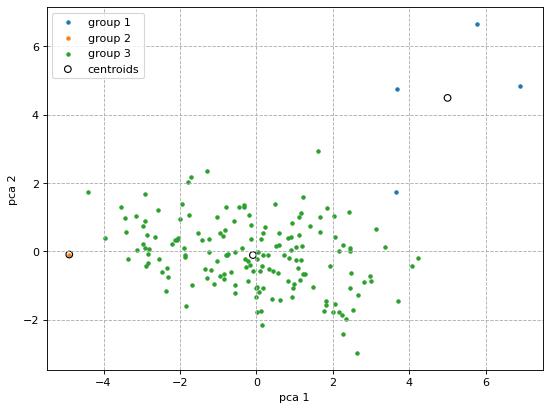

```python
fit_and_plot(X, 3, ks, best_Cs)
```

```
Group 1:
   Afghanistan, Angola, Benin, Botswana, Burkina Faso, Burundi, Cameroon, Central African Republic, Chad, Comoros, Congo, Dem. Rep., Congo, Rep., Cote d'Ivoire, Equatorial Guinea, Eritrea, Gabon, Gambia, Ghana, Guinea, Guinea-Bissau, Haiti, India, Iraq, Kenya, Kiribati, Lao, Lesotho, Liberia, Madaga…
Group 2:
   Nigeria
Group 3:
   Albania, Algeria, Antigua and Barbuda, Argentina, Armenia, Australia, Austria, Azerbaijan, Bahamas, Bahrain, Bangladesh, Barbados, Belarus, Belgium, Belize, Bhutan, Bolivia, Bosnia and Herzegovina, Brazil, Brunei, Bulgaria, Cambodia, Canada, Cape Verde, Chile, China, Colombia, Costa Rica, Croatia…
Group 4:
   Luxembourg, Malta, Singapore
```

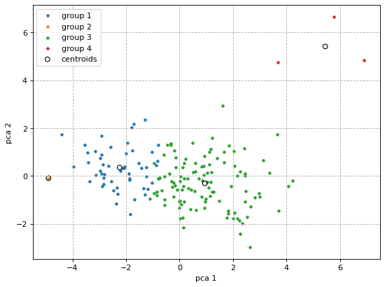

```python
fit_and_plot(X, 4, ks, best_Cs)
```

- For `k=3`, the clusters are: tax havens, Nigeria, and everyone else.
- For `k=4`, the clusters are: tax havens, Nigeria, poor countries, and everyone else.

### Implementing Gaussian Mixture Model

An alternative to k-means clustering. Assume the datapoints in each cluster follow a Gaussian distribution, as we saw with Gaussian Discriminative Analysis (`iris.ipynb`). The difference is that this is an unsupervised learning problem and we don't know the clusters, so we use the Expectation-Maximisation (EM) algorithm to find the parameters of the distributions, as follows:

1. Initialize the parameters to reasonable values.
2. Expectation step. Update the probability that each datapoint belongs to each cluster, according to the parameters. (See: Gaussian Distriminative Analysis).
3. Maximisation step. Maximise the likelihood of the observations, as a function of the parameters, i.e. update the parameters to maximise the likelihood. The updates are derived by taking the derivative of the log likelihood of the data with respect to the various parameters.
4. Repeat from step 2 until the likelihood of the observations/datapoints has converged.

Once we've fit the parameters, we know the cluster that each observation is most likely to belong to, which gives us our clustering.

As with k-means, this algorithm is sensitive to randomisation, and may require multiple runs for a good fit.

```python
class GaussianMixture:
    def __init__(self, k):
        self.k = k

    def fit(self, X, eps=.01):
        self._init_params(X)
        l = None
        while True:
            self._do_steps(X)
            l0 = self._log_likelihood(X)
            # likelihood should always increase, so difference should
            # always be positive. But just in case...
            if l is not None and abs(l0 - l) < eps:
                break
            l = l0
        return self.predict(X)

    def _do_steps(self, X):
        self._expectation_step(X)
        self._maximisation_step(X)

    def _init_params(self, X):
        self.N = len(X)
        self.cov_reg = 1e-6*np.eye(len(X[0]))
        self._init_model_params(X)
        # This array stores the posterior probability distribution for each
        # datapoint's latent variable.
        self.P_z_given_x = np.zeros((self.N, self.k))

    def _init_model_params(self, X):
        # Set the means to be random datapoints.
        self.means = X[np.random.choice(X.shape[0], self.k, replace=False), :]
        # Seed the covariance matrices with the sample covariance matrix over
        # all the data.
        A = X - np.mean(X, axis=0)
        cov = np.matmul(A.T, A) / self.N
        self.covs = np.array([cov[:] for _ in range(self.k)])
        # Use equal priors.
        self.P_z = np.repeat(1/self.k, self.k)

    def _expectation_step(self, X):
        self._compute_P_z_given_x(X, self.P_z_given_x)

    def _compute_P_z_given_x(self, X, storage_matrix):
        # If there are m clusters, then...
        #   P(z=k|x) = P(x,z=k)/P(x)
        #            = P(x,z=k)/(\sum_{j=1}^{m} P(x,z=j))
        #            = P(z=k)P(x|z=k)/(\sum_{j=1}^{m} P(z=j)P(x|z=j))
        # As with GDA, P(z=k) is the prior and P(x|z=k) is the probability
        # density of the gaussian distribution that models the k-th cluster.
        for j in range(self.k):
            # First calculate P(x,z=j) for all x & j.
            storage_matrix[:, j] = self._compute_P_x_and_zj(X, j)
        # Then normalise each P(x,z=j) by dividing by the sum over all values of j.
        storage_matrix /= np.sum(storage_matrix, axis=1)[:, np.newaxis]

    def _compute_P_x_and_zj(self, X, j):
        return self.P_z[j]*multivariate_normal.pdf(X, mean=self.means[j], cov=self.covs[j])

    def _maximisation_step(self, X):
        self.P_z[:] = np.sum(self.P_z_given_x, axis=0) / self.N
        # Zero the covariance matrices first 'cause we're going to
        # compute the new estimates by summing.
        self.covs[:] = 0
        for j in range(self.k):
            E_samples = np.sum(self.P_z_given_x[:,j])
            self.means[j] = (np.sum(self.P_z_given_x[:,j][:,None] * X, axis=0)
                             / E_samples)
            # There has to be a vectorised way of doing this...
            for i in range(self.N):
                a = X[i] - self.means[j]
                self.covs[j] += self.P_z_given_x[i,j] * np.matmul(a[:,np.newaxis], a[np.newaxis,:])
            # This is to make sure we don't get a singular covariance matrix when
            # the Gaussian basically collapses down to contain a single datapoint.
            # See: https://stats.stackexchange.com/questions/219302/singularity-issues-in-gaussian-mixture-model
            self.covs[j] += self.cov_reg
            self.covs[j] /= E_samples

    def _log_likelihood(self, X):
        # If theta represents all the parameters of the model, the log likelihood
        # given a set of observations {x} is
        #   l(theta) = \sum_{x} log P(x|theta).
        #            = \sum_{x} log(\sum_{j} P(x,z=j))
        # I think it's okay to use the density for P(x|z=j).
        likelihood_by_x = np.zeros(self.N)
        for j in range(self.k):
            # Redundant computation here, we're doing the same thing in the
            # expectation step.
            likelihood_by_x += self._compute_P_x_and_zj(X, j)
        return np.sum(np.log(likelihood_by_x))

    def predict(self, X):
        N = len(X)
        max_likelihood = np.zeros(N)
        result = np.zeros(N, dtype=np.uint)
        for j in range(self.k):
            likelihood = self._compute_P_x_and_zj(X, j)
            mask = likelihood > max_likelihood
            result[mask] = j
            max_likelihood[mask] = likelihood[mask]
        return result
```

Test on some relatively simple data. Actual gaussian distributions.

```python
u1 = np.array([2., 3.])
cov1 = np.eye(2, dtype=float)
N1 = 100
u2 = np.array([-2., -2.])
cov2 = np.array([[2., .3], [.3, 1.]])
N2 = 150
X = np.vstack([
    np.random.multivariate_normal(u1, cov1, N1),
    np.random.multivariate_normal(u2, cov2, N2),
])
y = np.concatenate([np.repeat(0, N1), np.repeat(1, N2)])
```

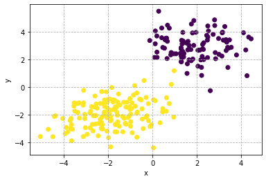

```python
plt.scatter(*zip(*X), c=y)
plt.grid(linestyle="--")
plt.xlabel("x")
plt.ylabel("y")
```

```python
model = GaussianMixture(2)
model.fit(X)
```

Oops, the group IDs of the model don't match those we assigned ourselves.

```python
pred = model.predict(X)
correct = (pred == y)
print(np.sum(correct))
```

```
1
```

Fix that.

```python
pred = (pred+1) % 2
correct = (pred == y)
print(np.sum(correct))
```

```
249
```

Plotting the means of the two clusters as well as any incorrectly-classified points. We see that 1 outlier from the yellow group got classified as part of the purple group. Also, the predicted means came very close to the real ones.

```
Likelihood: -905.1927796905122
```

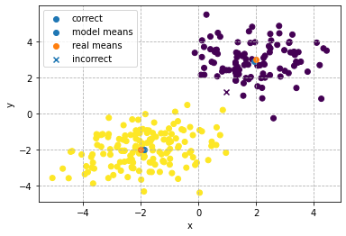

```python
print("Likelihood:", model._log_likelihood(X))
plt.scatter(*zip(*X[correct]), c=y[correct], label="correct")
plt.scatter(*zip(*model.means), label="model means")
plt.scatter(*zip(*np.vstack([u1, u2])), label="real means")
plt.scatter(*zip(*X[~correct]), marker="x", c=pred[~correct], label="incorrect")
plt.grid(linestyle="--")
plt.xlabel("x")
plt.ylabel("y")
plt.legend()
```

### Applying GMM to country clustering

```python
X = df.drop(["country"], axis=1).to_numpy()
```

```python
runs_per_k = 5
ks = [2, 3, 4, 5, 6]
best_clusterings = []
scores = []
for k in ks:
    print("k:", k)
    score = -2
    best_clustering = None
    for _ in range(runs_per_k):
        model = GaussianMixture(k)
        clustering = model.fit(X)
        new_score = silhouette_score(X, k, clustering)
        if new_score > score:
            best_clustering = clustering
            score = new_score
    best_clusterings.append(best_clustering)
    scores.append(score)
```

```
k: 2
k: 3
k: 4
k: 5
k: 6
```

Silhouette score seems to indicate the 2 clusters is optimal.

```
(-1.0, 1.0)
```

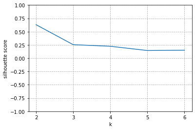

```python
plt.plot(ks[:len(scores)], scores)
plt.xlabel("k")
plt.ylabel("silhouette score")
plt.axes().xaxis.set_major_locator(MaxNLocator(integer=True))
plt.grid(linestyle="--")
plt.ylim(bottom=-1, top=1)
```

Interesting! `k=2` is the best fit according to the silhouette score, but the actual clustering it produces basically implies that all the datapoints are generated by a single Gaussian. This actually makes sense -- eyeballing the data, it DOES seem to come from a single Gaussian! `k=3` is closer to the clustering produced by k-means: haves, have-nots, and tax tavens. For `k>3`, the clusters are harder to distinguish (spatially) in 2 dimensions. An alternative dimensionality reduction method might show the clusters better.

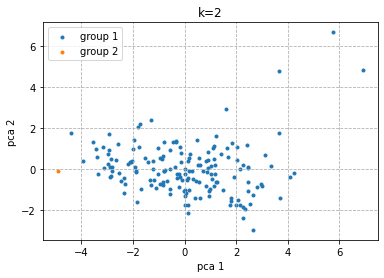

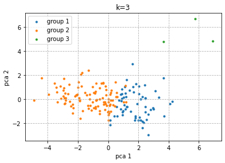

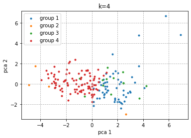

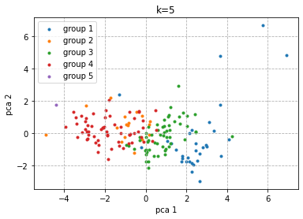

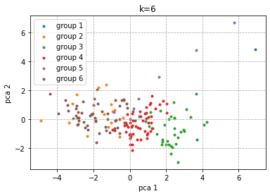

```python
for k, clustering in zip(ks, best_clusterings):
    for i in range(k):
        plt.scatter(*zip(*pca_data[clustering==i]),
                    marker=".",
                    label=f"group {i+1}")
    plt.xlabel("pca 1")
    plt.ylabel("pca 2")
    plt.grid(linestyle="--")
    plt.title(f"k={k}")
    plt.legend()
    plt.show()
```

### Conclusions

We've seen how the k-means algorithm and the gaussian mixture model can be applied to clustering of country data. According to the metrics we examined, the optimal number of clusters seems to be 2-4, though I'm not sure that this is an actually useful way to divide countries for the purposes of allocating NGO resources.

Future work:

- Exploratory analysis to characterise the clusters. Why does Nigeria end up in its own cluster? What makes a tax haven a tax haven?
- Alternative methods of picking the starting point for clusters.
- Alternative dimensionality reduction methods.